# Reconhecimento de Padrão

Lania Barros Gomes Martins

31/01/2023

# 1 Contextualização

Será usada o dataset BreastCancer disponível no pacote “mlbench”. Na base constam 699 observações em 11 variáveis referentes a identificação de classes benígnas e malígnas. Foi observado 16 valores de atributos ausentes.

# 2 Objetivo

# 3 Análise de Componentes Principais

## 3.1 Carregamento dos pacotes

```r
library(devtools)
library(factoextra)
library(FactoMineR)
library(mlbench)
library(corrplot)
```

## 3.2 Leitura e visualização do banco de dados

```r
data(BreastCancer)

dados<- BreastCancer[,-c(1)]

str(dados)
```

```
## 'data.frame':    699 obs. of  10 variables:
##  $ Cl.thickness   : Ord.factor w/ 10 levels "1"<"2"<"3"<"4"<..: 5 5 3 6 4 8 1 2 2 4 ...
##  $ Cell.size      : Ord.factor w/ 10 levels "1"<"2"<"3"<"4"<..: 1 4 1 8 1 10 1 1 1 2 ...
##  $ Cell.shape     : Ord.factor w/ 10 levels "1"<"2"<"3"<"4"<..: 1 4 1 8 1 10 1 2 1 1 ...
##  $ Marg.adhesion  : Ord.factor w/ 10 levels "1"<"2"<"3"<"4"<..: 1 5 1 1 3 8 1 1 1 1 ...
##  $ Epith.c.size   : Ord.factor w/ 10 levels "1"<"2"<"3"<"4"<..: 2 7 2 3 2 7 2 2 2 2 ...
##  $ Bare.nuclei    : Factor w/ 10 levels "1","2","3","4",..: 1 10 2 4 1 10 10 1 1 1 ...
##  $ Bl.cromatin    : Factor w/ 10 levels "1","2","3","4",..: 3 3 3 3 3 9 3 3 1 2 ...
##  $ Normal.nucleoli: Factor w/ 10 levels "1","2","3","4",..: 1 2 1 7 1 7 1 1 1 1 ...
##  $ Mitoses        : Factor w/ 9 levels "1","2","3","4",..: 1 1 1 1 1 1 1 1 5 1 ...
##  $ Class          : Factor w/ 2 levels "benign","malignant": 1 1 1 1 1 2 1 1 1 1 ...
```

```r
head(dados[,-10])
```

```
##   Cl.thickness Cell.size Cell.shape Marg.adhesion Epith.c.size Bare.nuclei
## 1            5         1          1             1            2           1
## 2            5         4          4             5            7          10
## 3            3         1          1             1            2           2
## 4            6         8          8             1            3           4
## 5            4         1          1             3            2           1
## 6            8        10         10             8            7          10
##   Bl.cromatin Normal.nucleoli Mitoses
## 1           3               1       1
## 2           3               2       1
## 3           3               1       1
## 4           3               7       1
## 5           3               1       1
## 6           9               7       1
```

## 3.3 Tratamento das variáveis

```r
for (i in 1:10){
  dados[,i] <- as.numeric(dados[,i])
}
```

As variáveis factor foram convertidas para numéricas para criação do PCA.

## 3.4 Verificação de dados faltantes na base de dados

```r
any(is.na(dados))
```

```
## [1] TRUE
```

### 3.4.1 Percentual de dados faltantes

```r
NAS <- round(colSums(is.na(dados))*100/nrow(dados),2)
NAS[NAS>0]
```

```
## Bare.nuclei
##        2.29
```

Somente a coluna Bare.Nuclei apresenta dados NA.

### 3.4.2 Exclusão das observações com dados faltantes

Como eram poucos dados NA, optou-se por excluir essas linhas.

```r
df <- na.omit(dados)
```

A base passou de 699 para 683 observações.

### 3.4.3 Correlação entre variáveis

Verificação da existência de correlação entre as variáveis.

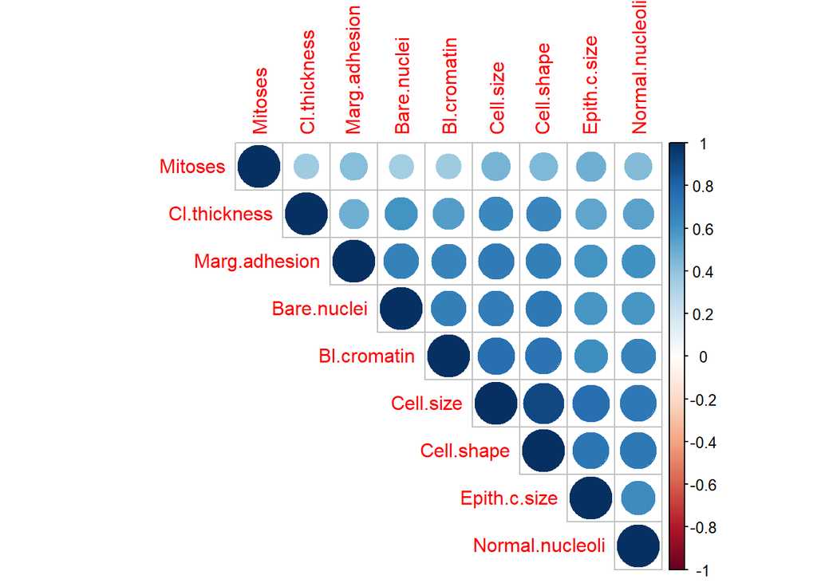

```r
#resultado=rcorr(as.matrix(df[,-10]))

corrplot(cor(df[,-10]), type="upper", order="hclust",
         sig.level = 0.01, insig = "blank")
```

## 3.5 Cálculo Matriz de Covariança

Para calcular os componetes principais foram usadas 9 variáveis núméricas.

```r
pca_Cov <- princomp(df[,-10],cor = FALSE, scores = TRUE)

summary(pca_Cov)
```

```
## Importance of components:
##                           Comp.1     Comp.2     Comp.3     Comp.4     Comp.5
## Standard deviation     6.9936860 2.25282585 2.07253047 1.77310753 1.65921243
## Proportion of Variance 0.6927726 0.07188424 0.06083875 0.04452958 0.03899262
## Cumulative Proportion  0.6927726 0.76465688 0.82549564 0.87002522 0.90901784
##                            Comp.6    Comp.7     Comp.8    Comp.9
## Standard deviation     1.51665955 1.3342171 1.23998279 0.8975748
## Proportion of Variance 0.03258027 0.0252134 0.02177759 0.0114109
## Cumulative Proportion  0.94159811 0.9668115 0.98858910 1.0000000
```

### 3.5.1 Pesos (autovetores da matrix de covariância)

```r
pca_Cov$loadings
```

```
##
## Loadings:
##                 Comp.1 Comp.2 Comp.3 Comp.4 Comp.5 Comp.6 Comp.7 Comp.8 Comp.9
## Cl.thickness     0.297         0.852         0.410
## Cell.size        0.404 -0.234         0.309 -0.316  0.108 -0.197         0.725
## Cell.shape       0.393 -0.169         0.221 -0.351  0.111 -0.384 -0.181 -0.668
## Marg.adhesion    0.331  0.101 -0.473  0.386  0.673        -0.164  0.143
## Epith.c.size     0.250 -0.198         0.186 -0.224 -0.447  0.408  0.658 -0.114
## Bare.nuclei      0.443  0.782        -0.304 -0.209 -0.202
## Bl.cromatin      0.292        -0.123                0.555  0.729 -0.220
## Normal.nucleoli  0.355 -0.475 -0.135 -0.753  0.186        -0.147
## Mitoses          0.119 -0.155         0.101  0.157 -0.648  0.250 -0.666
##
##                Comp.1 Comp.2 Comp.3 Comp.4 Comp.5 Comp.6 Comp.7 Comp.8 Comp.9
## SS loadings     1.000  1.000  1.000  1.000  1.000  1.000  1.000  1.000  1.000
## Proportion Var  0.111  0.111  0.111  0.111  0.111  0.111  0.111  0.111  0.111
## Cumulative Var  0.111  0.222  0.333  0.444  0.556  0.667  0.778  0.889  1.000
```

### 3.5.2 Mostrando os scores das seis primeiras linhas

```r
head(pca_Cov$scores)
```

```
##      Comp.1      Comp.2      Comp.3      Comp.4     Comp.5     Comp.6
## 1 -4.479305 -0.02725444  1.71840384  0.06835366  0.8467727  0.6551744
## 2  4.829760  4.74052946 -0.99632955  0.63914884 -1.2784309 -2.4830409
## 3 -4.630058  0.61009461 -0.07778259 -0.31606768 -0.1819597  0.3657685
## 4  5.105714 -3.47960620  2.14940160 -1.42923273 -3.1491013  1.0507008
## 5 -4.113422  0.10234794 -0.08063885  0.80054920  1.7827071  0.7502498
## 6 15.026035  0.38266214 -0.67547771  1.16700655 -1.4111179  2.3938212
##        Comp.7      Comp.8      Comp.9
## 1  1.02766213 -0.02636493 -0.01999805
## 2  0.07972127  2.91478716 -0.00907619
## 3  0.88327362 -0.20452624  0.02856647
## 4 -3.61694561 -0.84349091  0.62547413
## 5  0.65255102  0.18002765 -0.11137123
## 6 -0.11819489  0.96520147 -0.15716297
```

Analisando o gráfico abaixo, podemos observar a possibilidade de, no mínimo, dois grupos. Além disso, Os dados a esquerda, das setas, apresentam valores mais baixos em relação as variáveis.

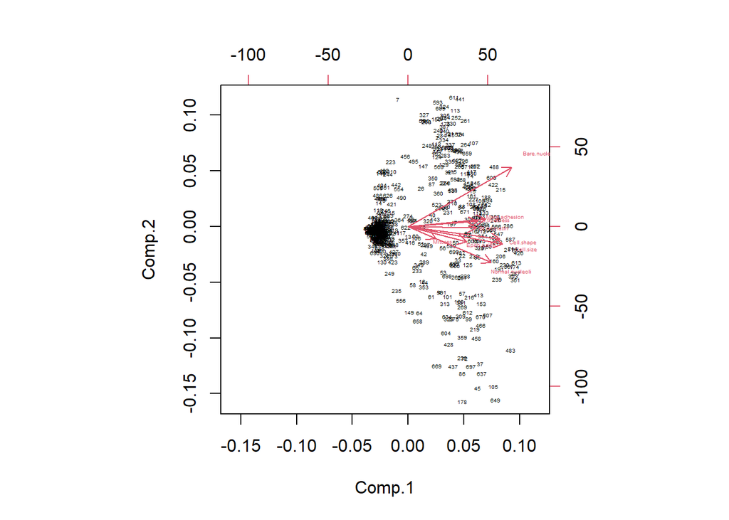

```r
biplot(pca_Cov, cex = 0.30)
```

### 3.5.3 Percentual de explicação dos componentes principais (PCA)

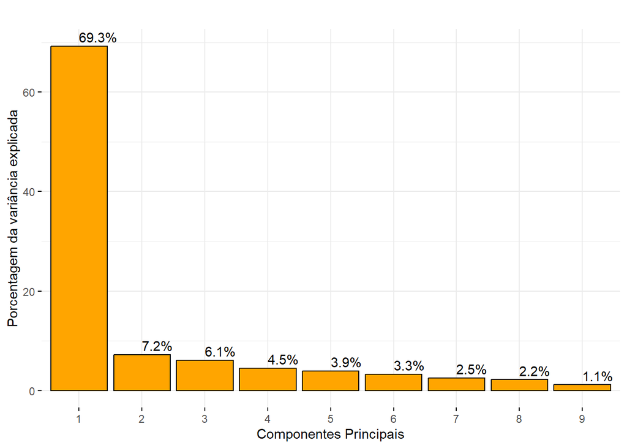

# 4 Análise de Agrupamento

Para nossa análise será utilizada como medida a **distância euclidiana Quadrática**.

## 4.1 Cálculo da distância Euclidiana

```r
D <- dist(df[,-11], method = "euclidian")^2
```

## 4.2 Agrupamento Hierárquico (vizinho mais distânte)

```r
agr <- hclust(D,method="complete")
```

## 4.3 Criação do Dendrograma

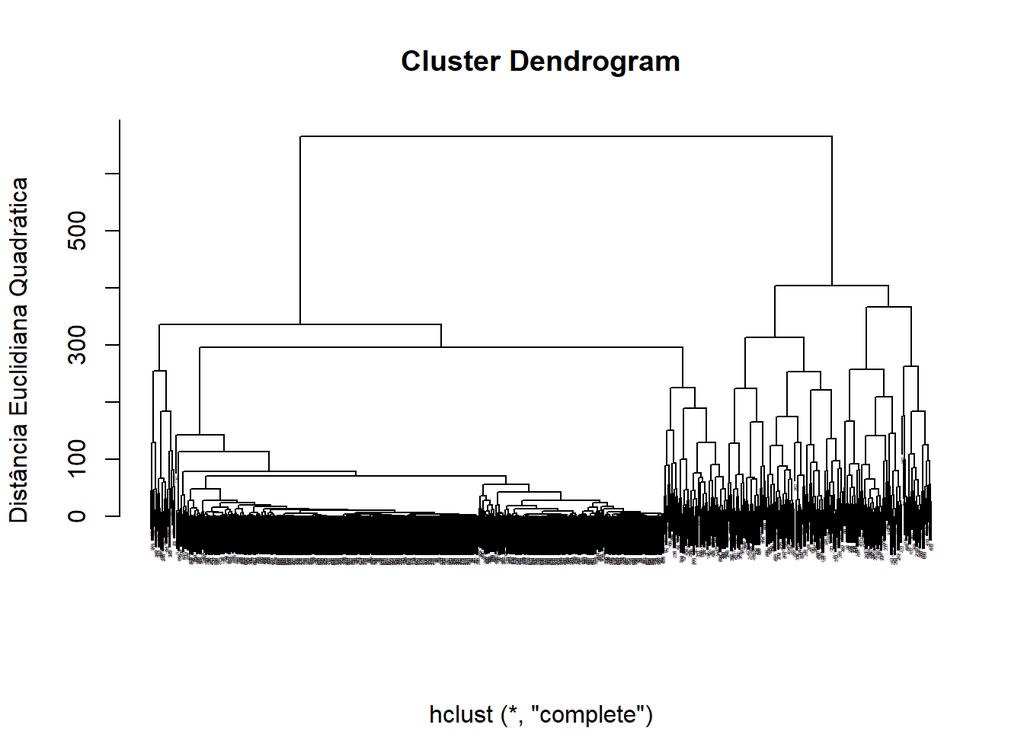

```r
plot(agr, xlab=" ", ylab="Distância Euclidiana Quadrática", cex=0.20)
```

### 4.3.1 Qualidade dos agrupamentos (correlação cofenética)

```r
cof <- cophenetic(agr)
cor(cof,D)
```

```
## [1] 0.8470818
```

Podemos verificar que o agrupamento é satisfatório.

### 4.3.2 Otimização (K-médias)

Será adotado como método de otimização o K-médias.

Foi definido a divisão dos dados em 2 grupos.

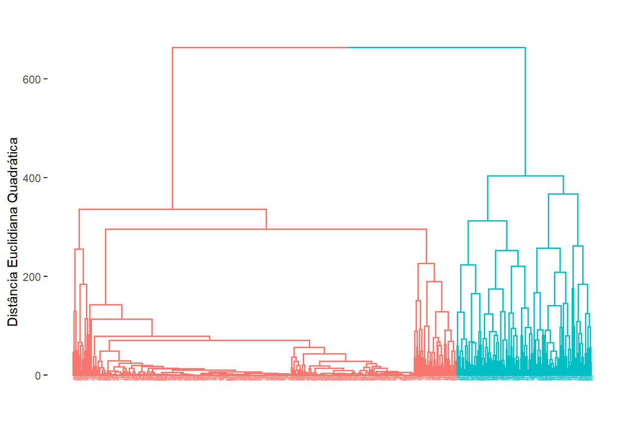

Análise da distribuição das observações pelos 2 grupos.

```r
km <- kmeans(x=df[,-11],2,nstart=20)
```

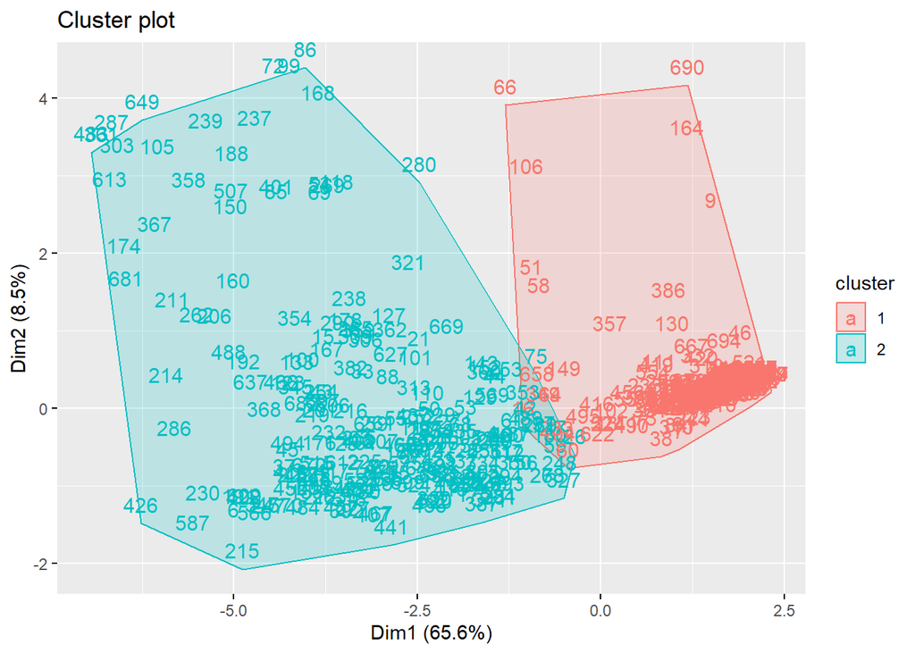

```r
fviz_cluster(km, df[, -10], geom = "text")
```

# 5 Conclusão

Através de técnicas de agrupamento, podemos analisar a distribuição das observações nos dois grupos.

# 6 Referências

- [Infomações sobre o dataset utilizado] https://cran.r-project.org/web/packages/mlbench/mlbench.pdf
- [E-Book - Software R para avaliação de dados experimentais:] https://tiagoolivoto.github.io/e-bookr/multivariate.html